# Task13

Tomas Kozlovskis

2016 m balandis 26 d

## TASK 13.1

### For the following series, find an appropriate Box-Cox transformation and order of differencing in order to obtain stationary data.

#### (a) usnetelec

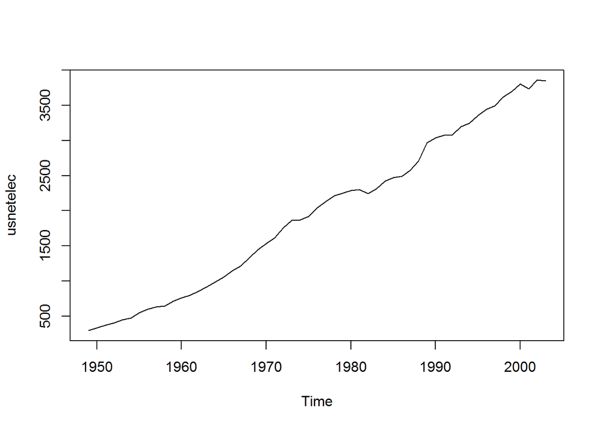

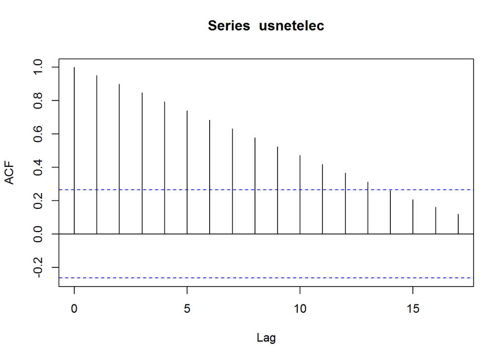

Data seems to have a trend.

```r
nd<-ndiffs(usnetelec)
usnetelec_d<-diff(usnetelec, differences = nd)
```

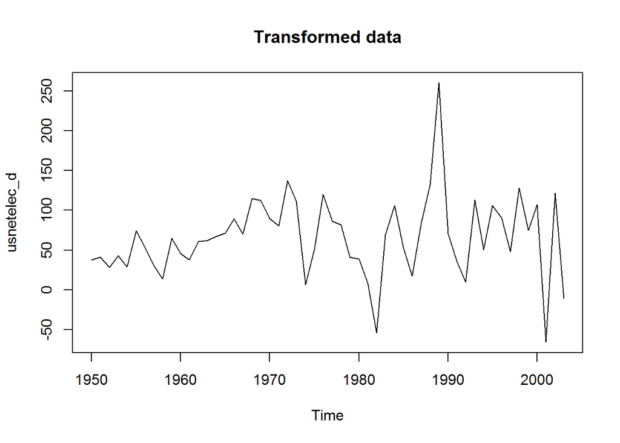

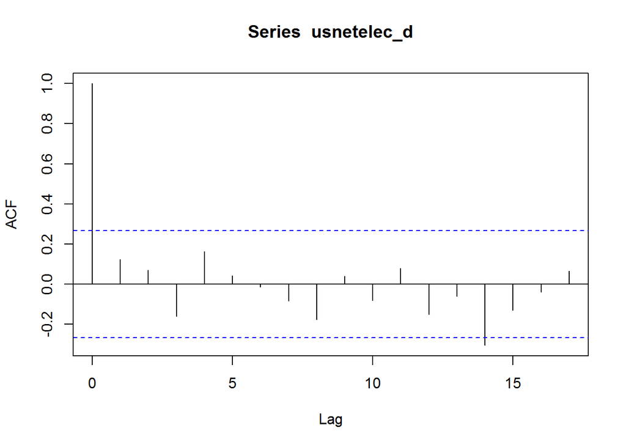

```
##
##  KPSS Test for Level Stationarity
##
## data:  usnetelec_d
## KPSS Level = 0.1656, Truncation lag parameter = 1, p-value = 0.1
```

Number of differences is 1. After differencing, we are using $kpss.test$ to determine if now data is stationary. Test gives a p-value higher than 0.05, which means that we cannot deny null hypothesis that time series is stationary.